# Report_12.Rmd

# 1 Введение

## 1.1 Анализ вклада социальных, поведентческих и медицинских факторов на степень нарушения гликемического контроля в смешанной когорте из 4000 пациентов

В нашем распоряжении оказался набор данных о пациентах: их клинической истории, образе жизни, биохимических показателях, социальных компонентах их жизни. Весьма исчерпывающий объем информации, представленный в имеющеся датасете позволяет исследовать основные предикторы развития диабета, а так же изучить распределение этого заболевания среди населения и зависимость его возникновения от разнообразных факторов.

# 2 Разведочный анализ данных (EDA) и коррекция

## 2.1 Описание переменных

В полученном датасете представлена следующая информация о пациентах:

- **Возраст и пол**
- **Сведения о социальных показателях**: национальность, уровень образования и доход, статус трудоустройства. Категориальные данные.
- **Информация об образе жизни**: курение, потребление алкоголя, физическая активность, диета, количество сна, экранное время.
- **Клиническая история**: наличие диабета в семье, наличие проблем с кровяным давлением или болезней сердца и сосудов.
- **Антропометрические показатели**: ИМТ и отношение размера талии к бедрам.
- **Клинические и биохимические показатели**: кровяное давление, ЧСС, уровень холестерола, триглицеридов, глюкозы, инсулина, hba1c
- Также представлены сведения о рисках развития диабета, типе заболевания и наличии диабета в целом.

## 2.2 Проверка значений переменных

### 2.2.1 Работа с пропущенными значениями

```r
table(is.na(data))
```

```
##
##  FALSE
## 124000
```

Нам повезло, пропущенных значений в наборе данных нет.

### 2.2.2 Проверка типов переменных и устранение недочетов

При загрузке датафрейма типы данных были установлены автоматически:

| Переменная | Тип данных |
| --- | --- |
| age | numeric |
| gender | character |
| ethnicity | character |
| education_level | character |
| income_level | character |
| employment_status | character |
| smoking_status | character |
| alcohol_consumption_per_week | numeric |
| physical_activity_minutes_per_week | numeric |
| diet_score | numeric |
| sleep_hours_per_day | numeric |
| screen_time_hours_per_day | numeric |
| family_history_diabetes | numeric |
| hypertension_history | numeric |
| cardiovascular_history | numeric |
| bmi | numeric |
| waist_to_hip_ratio | numeric |
| systolic_bp | numeric |
| diastolic_bp | numeric |
| heart_rate | numeric |
| cholesterol_total | numeric |
| hdl_cholesterol | numeric |
| ldl_cholesterol | numeric |
| triglycerides | numeric |
| glucose_fasting | numeric |
| glucose_postprandial | numeric |
| insulin_level | numeric |
| hba1c | numeric |
| diabetes_risk_score | numeric |
| diabetes_stage | character |
| diagnosed_diabetes | numeric |

Переменные, которые являются категориальными, оказались либо строковыми, либо численными. Перед приведением их к факторам убедимся, что среди категориальных данных нет ошибок или опечаток

```
## $gender
## [1] "Female" "Male"   "Other"
##
## $ethnicity
## [1] "Hispanic" "White"    "Black"    "Asian"    "Other"
##
## $education_level
## [1] "Graduate"     "Highschool"   "Postgraduate" "No formal"
##
## $income_level
## [1] "Middle"       "Lower-Middle" "Upper-Middle" "Low"          "High"
##
## $employment_status
## [1] "Employed"   "Student"    "Retired"    "Unemployed"
##
## $smoking_status
## [1] "Never"   "Current" "Former"
##
## $family_history_diabetes
## [1] 1 0
##
## $hypertension_history
## [1] 0 1
##
## $cardiovascular_history
## [1] 0 1
##
## $diabetes_stage
## [1] "Type 2"       "No Diabetes"  "Pre-Diabetes" "Gestational"  "Type 1"
##
## $diagnosed_diabetes
## [1] 1 0
```

С данными все хорошо, спокойно присваиваем им факторный тип.

### 2.2.3 Работа с выбросами

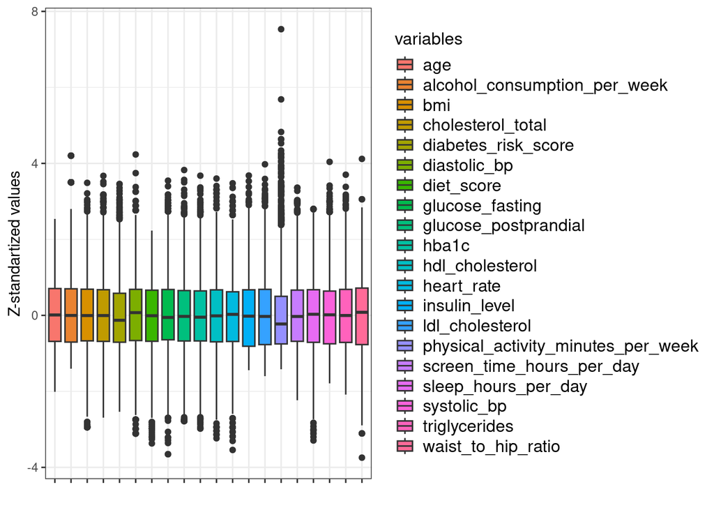

Ввиду разных масштабов имеющихся числовых данных было принято решение провести Z-стандартизацию значений для упрощения восприятия визуализации выбросов, представленной выше.

В глаза бросается самый высокий выброс в переменной `physical activity`, однако если посмотреть на его значение, то станет ясно, что этот пациент занимается физ. нагрузками около 12 часов в неделю, что может быть вполне реалистично. Этот выброс соответствует пациентке 39 лет, курящей и употребляющей алкоголь в среднем 5 раз в неделю, с индексом массы тела 29.9 и диагностированным диабетом.

Остальные значения, оказавшиеся за пределами межквартильного размаха, также являются реалистичными.

| Age | Gender | Smoking | Alcohol Consumption per Week | Physical activity, min/week | Diagnosed Diabetes | Diabetes Stage |
| --- | --- | --- | --- | --- | --- | --- |
| 39 | Female | Current | 5 | 751 | yes | Type 2 |

Таким образом, в имеющемся наборе данных не было обнаружен выбросов, похожих на ошибки наблюдений. Мы проверили наличие отсутствующих значений и выбросов, а также привели все переменные к надлежащим типам данных. Можем ознакомиться с базовыми описательными статистиками и приступать к проверке гипотез.

| Variables | mean | sd | median | min | max |
| --- | --- | --- | --- | --- | --- |
| age | 49.82 | 15.83 | 50.00 | 18.00 | 90.00 |
| alcohol_consumption_per_week | 2.00 | 1.43 | 2.00 | 0.00 | 8.00 |
| physical_activity_minutes_per_week | 118.97 | 83.92 | 100.00 | 0.00 | 751.00 |
| diet_score | 6.02 | 1.79 | 6.00 | 0.00 | 10.00 |
| sleep_hours_per_day | 6.97 | 1.08 | 7.00 | 3.40 | 10.00 |
| screen_time_hours_per_day | 5.97 | 2.45 | 5.90 | 0.50 | 14.20 |
| bmi | 25.62 | 3.61 | 25.60 | 15.00 | 38.20 |
| waist_to_hip_ratio | 0.86 | 0.05 | 0.86 | 0.68 | 1.05 |
| systolic_bp | 115.78 | 14.41 | 116.00 | 90.00 | 174.00 |
| diastolic_bp | 75.41 | 8.17 | 76.00 | 50.00 | 110.00 |
| heart_rate | 69.77 | 8.41 | 70.00 | 40.00 | 99.00 |
| cholesterol_total | 187.13 | 32.37 | 187.00 | 100.00 | 306.00 |
| hdl_cholesterol | 54.12 | 10.24 | 54.00 | 21.00 | 91.00 |
| ldl_cholesterol | 103.93 | 33.72 | 103.00 | 50.00 | 238.00 |
| triglycerides | 121.11 | 43.73 | 121.00 | 30.00 | 283.00 |
| glucose_fasting | 109.73 | 13.61 | 109.00 | 60.00 | 158.00 |
| glucose_postprandial | 155.82 | 30.89 | 155.00 | 70.00 | 274.00 |
| insulin_level | 9.12 | 4.93 | 9.02 | 2.00 | 27.27 |
| hba1c | 6.40 | 0.81 | 6.36 | 4.00 | 9.37 |
| diabetes_risk_score | 29.76 | 9.01 | 28.60 | 6.90 | 60.90 |

```
##     gender        ethnicity        education_level       income_level
##  Female:1946   Asian   : 463   Graduate    :1387   High        : 177
##  Male  :1980   Black   : 675   Highschool  :1830   Low         : 595
##  Other :  74   Hispanic: 768   No formal   : 191   Lower-Middle:1007
##                Other   : 223   Postgraduate: 592   Middle      :1430
##                White   :1871                       Upper-Middle: 791
##   employment_status smoking_status family_history_diabetes hypertension_history
##  Employed  :2369    Current: 812   no :3209                no :3019
##  Retired   : 887    Former : 797   yes: 791                yes: 981
##  Student   : 221    Never  :2391
##  Unemployed: 523
##
##  cardiovascular_history      diabetes_stage diagnosed_diabetes
##  no :3651               Gestational :  14   no :2000
##  yes: 349               No Diabetes : 390   yes:2000
##                         Pre-Diabetes:1596
##                         Type 1      :   8
##                         Type 2      :1992
```

Так же ниже представленна таблица корреляций:

[figure not shown]

Как видно из таблицы корреляции, существует слабая отрицательная корреляция между сердечным ритмом и физической активностью (-0.25), между риском диабета в баллах и физической активностью (-0.37). Умеренная положительная корреляция между систолическим давлением и возрастом (0.54), сильная положительная связь между баллами риска и семейной историей (0.72), и так далее.

# 3 Проверка гипотез

## 3.1 Гипотезы

### 3.1.1 Гипотеза 1

H0: После учета влияния возраста, индекса массы тела (ИМТ) и уровня физической активности, не существует статистически значимых различий в средних уровнях гликированного гемоглобина (HbA1c) между группами, определенными по полу, уровню образования и наличию семейной истории диабета.

Зависимость уровня HbA1c между групами. ANOVA

| Predictors | Sum Sq | Df | F value | Pr(>F) |
| --- | --- | --- | --- | --- |
| age | 57.3709582 | 1 | 98.7504352 | 0.0000000 |
| bmi | 41.5295988 | 1 | 71.4833094 | 0.0000000 |
| physical_activity_minutes_per_week | 28.4202446 | 1 | 48.9186797 | 0.0000000 |
| family_history_diabetes | 137.2528456 | 1 | 236.2480717 | 0.0000000 |
| gender | 0.2482658 | 2 | 0.2136652 | 0.8076280 |
| education_level | 0.4286378 | 3 | 0.2459326 | 0.8642738 |
| Residuals | 2,318.0669789 | 3,990 |  |  |

#### 3.1.1.1 Проверка допущений дисперсионного анализа

Проверка критериев применимости дисперсионного анализа:

Проверка предикторов на мультиколлинеарность

| Predictors | GVIF | Df | GVIF^(1/(2*Df)) |
| --- | --- | --- | --- |
| age | 1.011804 | 1 | 1.005885 |
| bmi | 1.018884 | 1 | 1.009398 |
| physical_activity_minutes_per_week | 1.008369 | 1 | 1.004176 |
| family_history_diabetes | 1.001497 | 1 | 1.000748 |
| gender | 1.001929 | 2 | 1.000482 |
| education_level | 1.002856 | 3 | 1.000475 |

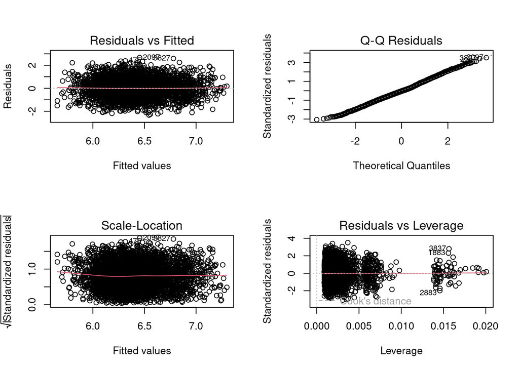

1. Линейность свяи (Residuals vs Fitted)

График остатков от предсказанных значений (Residuals vs Fitted) не выявил систематических нелинейных паттернов, что позволяет считать предположение о линейности выполненным.

2. Нормальность остатков (Q-Q plot)

```
##
##  Shapiro-Wilk normality test
##
## data:  residuals(hba1c_model)
## W = 0.99765, p-value = 8.341e-06
```

Тест Шапиро-Уилка показал статистически значимое отклонение от нормальности (W = 0.99765, p-value = 8.341e-06). Однако, учитывая очень большой объем выборки (n = 4000), F-критерий ANOVA является устойчивым к умеренным отклонениям от нормальности.

3. Постоянство дисперсий (гомоскедастичность) (Scale-Location plot)

```
##
##  studentized Breusch-Pagan test
##
## data:  hba1c_model
## BP = 13.479, df = 9, p-value = 0.1421
```

Тест Бройша-Пагана не значим (BP = 13.479, df = 9, p-value = 0.1421). Это свидетельствует об отсутствии гетероскедастичности, и предположение о постоянстве дисперсии остатков не нарушено.

4. Отсутствие мультиколлинеарности

```
##                                        GVIF Df GVIF^(1/(2*Df))
## age                                1.011804  1        1.005885
## bmi                                1.018884  1        1.009398
## physical_activity_minutes_per_week 1.008369  1        1.004176
## family_history_diabetes            1.001497  1        1.000748
## gender                             1.001929  2        1.000482
## education_level                    1.002856  3        1.000475
```

Все значения фактора инфляции дисперсии (VIF) находятся в диапазоне от 1.001 до 1.019, что значительно ниже общепринятого порога в 5-10. Это указывает на отсутствие проблем мультиколлинеарности между предикторами в модели.

5. Независимость наблюдений

```
##
##  Durbin-Watson test
##
## data:  hba1c_model
## DW = 1.9842, p-value = 0.3085
## alternative hypothesis: true autocorrelation is greater than 0
```

Тест Дарбина-Уотсона не значим (DW = 1.9842, p-value = 0.3085), что позволяет принять гипотезу об отсутствии автокорреляции остатков и считать наблюдения независимыми.

Условия применимости дисперсионного анализа в целом соблюдены. Нарушение нормальности остатков, выявленное тестом Шапиро-Уилка, не является критичным для выводов из-за большого объема выборки.

#### 3.1.1.2 Вывод гипотезы 1

Вывод: Мы отвергаем нулевую гипотезу (H0) в отношении факторов возраста, ИМТ, уровня физической активности и наличия семейной истории диабета. Эти предикторы демонстрируют статистически значимую (p < 0.001) связь с уровнем HbA1c после учета влияния других переменных в модели.

При этом у нас нет достаточных оснований отвергнуть нулевую гипотезу (H0) в отношении факторов пола (p = 0.8076) и уровня образования (p = 0.8643).

То есть, последние два фактора в данной спецификации модели не несут статистически значимой объясняющей способности для вариации HbA1c.

Пояснение: После учета влияния возраста, ИМТ и физической активности, наличие семейной истории диабета является мощным статистически значимым предиктором уровня HbA1c. Пол и уровень образования не оказывают статистически значимого влияния на вариацию уровня HbA1c в данной модели. Это означает, что средние уровни HbA1c не различаются значимо между группами по полу, а также между группами с разным уровнем образования.

### 3.1.2 Гипотеза 2

#### 3.1.2.1 Зависит ли уровень инсулина в крови пациента от социо-экономических факторов в жизни пациента?

Известно, что [повышенный уровень инсулина является одной из предпосылок диабета](https://pubmed.ncbi.nlm.nih.gov/11118012/). Если среди социальных факторов удастся выявить предикторы повышенного уровня инсулина, то пациенты, оказавшиеся в группе риска, получат возможность предпринять своевременные меры и предотвратить развитие заболевания.

Нулевая гипотеза: социальные факторы в жизни пациента не влияют на уровень инсулина и искать предикторы нужно в другой группе параметров. Альтернативная гипотеза: социальные факторы оказывают эффект на уровень инсулина у пациентов.

#### 3.1.2.2 Выбор модели и подходящих параметров

Для начала определимся с выбранными предикторами.

В рамках первой проверки построим модель со следующими предикторами: `ethnicity`, `education_level`, `income_level`, `employment_status`.

Зависимость уровня инсулина от социальных предикторов. ANOVA

| Predictors | Sum Sq | Df | F value | Pr(>F) |
| --- | --- | --- | --- | --- |
| ethnicity | 73.81507 | 4 | 0.7583998 | 0.5522839 |
| education_level | 10.22336 | 3 | 0.1400507 | 0.9360424 |
| income_level | 158.49894 | 4 | 1.6284691 | 0.1641494 |
| employment_status | 98.79700 | 3 | 1.3534296 | 0.2551917 |
| Residuals | 96,965.03508 | 3,985 |  |  |

#### 3.1.2.3 Проверка допущений

Проверка предикторов на мультиколлинеарность

| Predictors | GVIF | Df | GVIF^(1/(2*Df)) |
| --- | --- | --- | --- |
| ethnicity | 1.010710 | 4 | 1.001333 |
| education_level | 1.007336 | 3 | 1.001219 |
| income_level | 1.015603 | 4 | 1.001937 |
| employment_status | 1.010051 | 3 | 1.001668 |

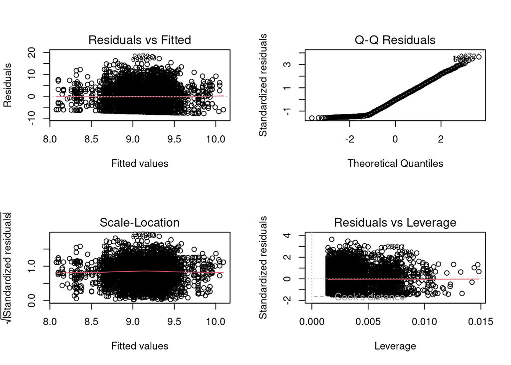

Показатель VIF оказался равен 1 для все предикторов модели, мультиколлинеарности между ними нет.

Однако, к сожалению, наша модель не удовлетворяет допущениям для проведения ANOVA. Данные распределены ненормально (QQplot), гомоскедантичности остатков не наблюдается, также на 4 графике видно смещение остатков в левую сторону. В связи с этим мы используем непараметрический тест, а именно проведем серию попарных сравнений с помощью теста Вилкоксона, основанного на сравнении медиан групп.

#### 3.1.2.4 Попарный тест Вилкоксона, p-values

```r
pairwise.wilcox.test(x = work_data$insulin_level, g = work_data$ethnicity)$p.value
```

```
##          Asian     Black Hispanic    Other
## Black        1        NA       NA       NA
## Hispanic     1 1.0000000       NA       NA
## Other        1 0.8075869        1       NA
## White        1 1.0000000        1 0.757925
```

```r
pairwise.wilcox.test(x = work_data$insulin_level, g = work_data$education_level)$p.value
```

```
##              Graduate Highschool No formal
## Highschool          1         NA        NA
## No formal           1          1        NA
## Postgraduate        1          1         1
```

```r
pairwise.wilcox.test(x = work_data$insulin_level, g = work_data$income_level)$p.value
```

```
##              High       Low Lower-Middle Middle
## Low             1        NA           NA     NA
## Lower-Middle    1 0.2550710           NA     NA
## Middle          1 1.0000000    0.9964487     NA
## Upper-Middle    1 0.3920466    1.0000000      1
```

```r
pairwise.wilcox.test(x = work_data$insulin_level, g = work_data$employment_status)$p.value
```

```
##             Employed   Retired   Student
## Retired    1.0000000        NA        NA
## Student    0.7491276 0.7491276        NA
## Unemployed 1.0000000 1.0000000 0.7491276
```

| Asian | Black | Hispanic | Other |
| --- | --- | --- | --- |
| 1 |  |  |  |
| 1 | 1.0000000 |  |  |
| 1 | 0.8075869 | 1 |  |
| 1 | 1.0000000 | 1 | 0.757925 |

| Graduate | Highschool | No formal |
| --- | --- | --- |
| 1 |  |  |
| 1 | 1 |  |
| 1 | 1 | 1 |

| High | Low | Lower-Middle | Middle |
| --- | --- | --- | --- |
| 1 |  |  |  |
| 1 | 0.2550710 |  |  |
| 1 | 1.0000000 | 0.9964487 |  |
| 1 | 0.3920466 | 1.0000000 | 1 |

| Employed | Retired | Student |
| --- | --- | --- |
| 1.0000000 |  |  |
| 0.7491276 | 0.7491276 |  |
| 1.0000000 | 1.0000000 | 0.7491276 |

Ни для одного из 4х предикторов не было выявлено значимого влияния на уровень инсулина. Уровень инсулина в крови не зависит от социальных факторов.Принимаем нулевую гипотезу.

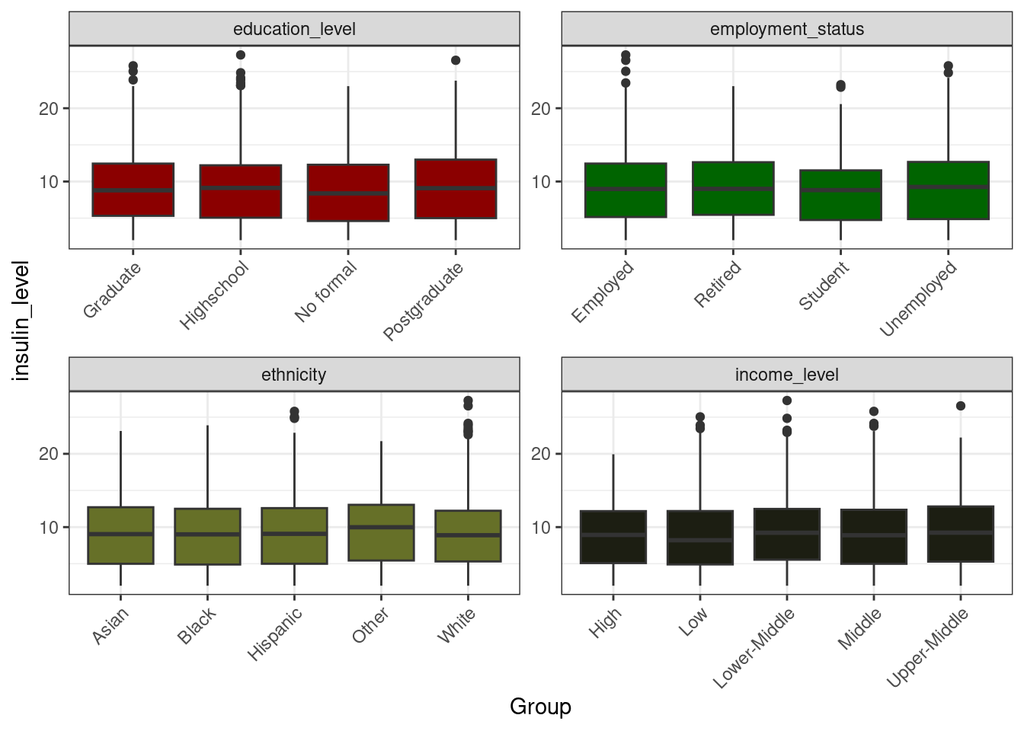

## 3.2 Модели

### 3.2.1 Модель 1

На основании значимых основных эффектов, выявленных в ANOVA, логичным следующим шагом будет проверка наличия статистически значимых взаимодействий между предикторами, в частности, между семейным анамнезом и модифицируемыми факторами риска.

Проверим конкретно взаимодействие между физической активностью в неделю и семейной историей диабета.

H0: Уровень HbA1c не зависит от взаимодействия между физической активностью в неделю и семейной историей диабета.

```
##
## Call:
## lm(formula = hba1c ~ age + physical_activity_minutes_per_week *
##     family_history_diabetes, data = data)
##
## Residuals:
##      Min       1Q   Median       3Q      Max
## -2.51471 -0.50772 -0.02231  0.49276  2.61899
##
## Coefficients:
##                                                              Estimate
## (Intercept)                                                 6.029e+00
## age                                                         8.281e-03
## physical_activity_minutes_per_week                         -1.103e-03
## family_history_diabetes                                     4.679e-01
## physical_activity_minutes_per_week:family_history_diabetes -3.973e-06
##                                                            Std. Error t value
## (Intercept)                                                 4.501e-02 133.962
## age                                                         7.681e-04  10.781
## physical_activity_minutes_per_week                          1.606e-04  -6.868
## family_history_diabetes                                     5.258e-02   8.899
## physical_activity_minutes_per_week:family_history_diabetes  3.723e-04  -0.011
##                                                            Pr(>|t|)
## (Intercept)                                                 < 2e-16 ***
## age                                                         < 2e-16 ***
## physical_activity_minutes_per_week                         7.51e-12 ***
## family_history_diabetes                                     < 2e-16 ***
## physical_activity_minutes_per_week:family_history_diabetes    0.991
## ---
## Signif. codes:  0 '***' 0.001 '**' 0.01 '*' 0.05 '.' 0.1 ' ' 1
##
## Residual standard error: 0.7687 on 3995 degrees of freedom
## Multiple R-squared:  0.09377,    Adjusted R-squared:  0.09286
## F-statistic: 103.3 on 4 and 3995 DF,  p-value: < 2.2e-16
```

#### 3.2.1.1 Проверка допущений линейной регрессии

Проверка критериев применимости линейной регрессии:

Проверка предикторов на мультиколлинеарность

| Predictors | vif(model_inter) |
| --- | --- |
| age | 1.000082 |
| physical_activity_minutes_per_week | 1.229927 |
| family_history_diabetes | 2.968941 |
| physical_activity_minutes_per_week:family_history_diabetes | 3.155714 |

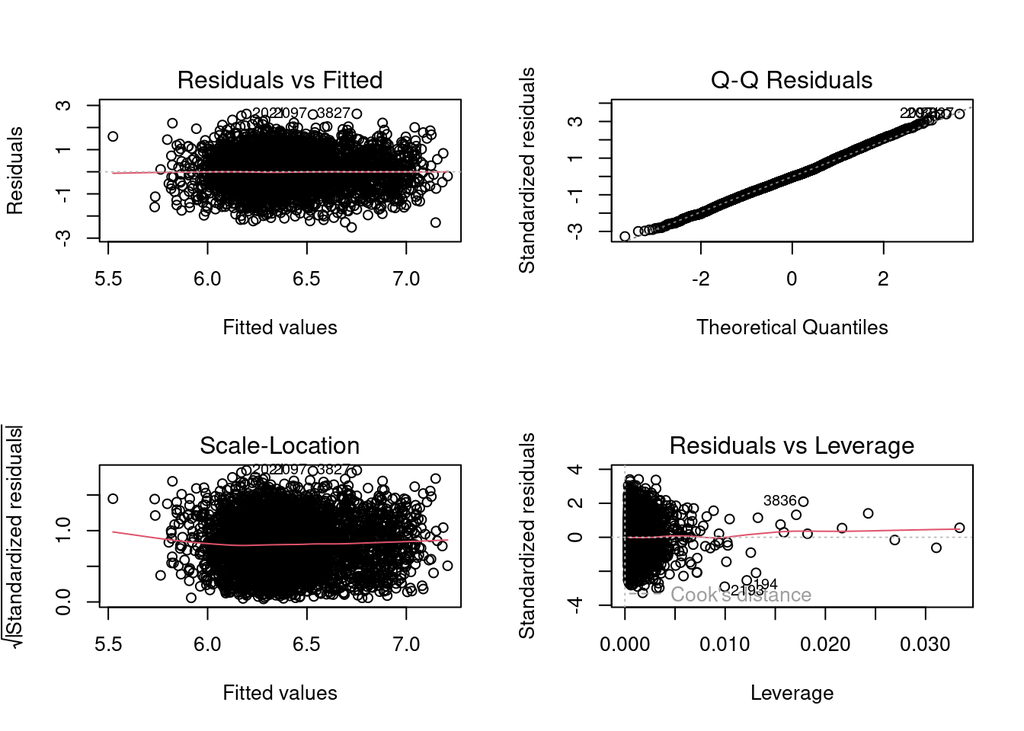

1. Линейность свяи (Residuals vs Fitted)

График остатков от предсказанных значений (Residuals vs Fitted) не выявил систематических нелинейных паттернов, что позволяет считать предположение о линейности выполненным.

2. Нормальность остатков (Q-Q plot)

```
##
##  Shapiro-Wilk normality test
##
## data:  residuals(model_inter)
## W = 0.99812, p-value = 0.0001002
```

3. Постоянство дисперсий (гомоскедастичность) (Scale-Location plot)

```
##
##  studentized Breusch-Pagan test
##
## data:  model_inter
## BP = 9.9249, df = 4, p-value = 0.04171
```

4. Отсутствие мультиколлинеарности

```
##                                                        age
##                                                   1.000082
##                         physical_activity_minutes_per_week
##                                                   1.229927
##                                    family_history_diabetes
##                                                   2.968941
## physical_activity_minutes_per_week:family_history_diabetes
##                                                   3.155714
```

5. Независимость наблюдений

```
##
##  Durbin-Watson test
##
## data:  model_inter
## DW = 1.9773, p-value = 0.2362
## alternative hypothesis: true autocorrelation is greater than 0
```

### 3.2.2 Модель 2

Попробуем определить основные предикторы диагностированного диабета среди клинических и биохимических данных. Так как зависимая переменная является категориальной, мы будем использовать общие линейные модели.

Проверка предикторов на мультиколлинеарность

| Predictors | vif(diabetes_model) |
| --- | --- |
| bmi | 1.474208 |
| systolic_bp | 1.110684 |
| diastolic_bp | 1.032396 |
| cholesterol_total | 1.073956 |
| triglycerides | 1.181782 |
| glucose_fasting | 1.024697 |
| insulin_level | 1.194993 |

Предикторы наличия диабета

| Estimate | Std. Error | z value | pvalue |
| --- | --- | --- | --- |
| -12.4691655212 | 0.6075596667 | -20.5233596 | 1.3e-93 |
| 0.0117288096 | 0.0127855785 | 0.9173468 | 3.6e-01 |
| 0.0016805322 | 0.0027790724 | 0.6047098 | 5.5e-01 |
| -0.0025125716 | 0.0046514941 | -0.5401644 | 5.9e-01 |
| 0.0007461546 | 0.0012011606 | 0.6211947 | 5.3e-01 |
| -0.0005067063 | 0.0009393519 | -0.5394212 | 5.9e-01 |
| 0.1106922577 | 0.0039298711 | 28.1668931 | 1.5e-174 |
| -0.0048819541 | 0.0082889708 | -0.5889699 | 5.6e-01 |

Среди предикторов не было выявлено мультиколлинеарности, однако единсвенным достоверно значимым предиктором оказался уровень глюкозы в крови при анализе крови натощак.

Проверим модель, основывающуюся исключительно на уровне глюкозы и влияние этого предиктора на постановку диагноза:

```
##
## Call:
## glm(formula = diagnosed_diabetes ~ glucose_fasting, family = "binomial",
##     data = work_data)
##
## Coefficients:
##                   Estimate Std. Error z value Pr(>|z|)
## (Intercept)     -12.188164   0.426472  -28.58   <2e-16 ***
## glucose_fasting   0.111224   0.003882   28.65   <2e-16 ***
## ---
## Signif. codes:  0 '***' 0.001 '**' 0.01 '*' 0.05 '.' 0.1 ' ' 1
##
## (Dispersion parameter for binomial family taken to be 1)
##
##     Null deviance: 5545.2  on 3999  degrees of freedom
## Residual deviance: 4225.8  on 3998  degrees of freedom
## AIC: 4229.8
##
## Number of Fisher Scoring iterations: 4
```

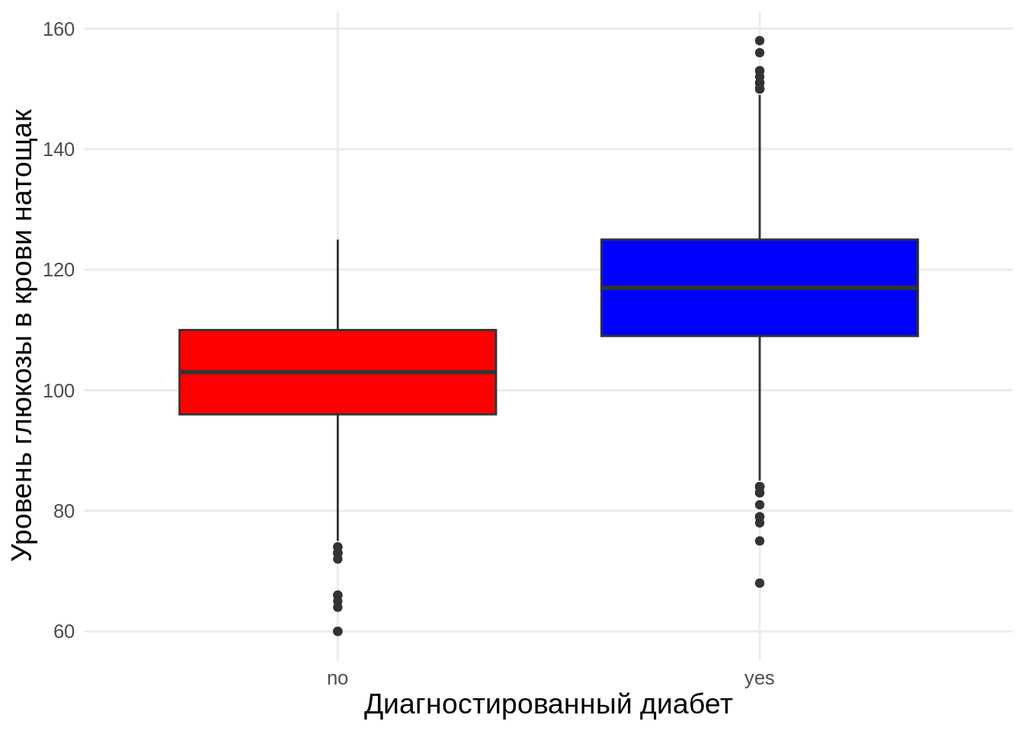

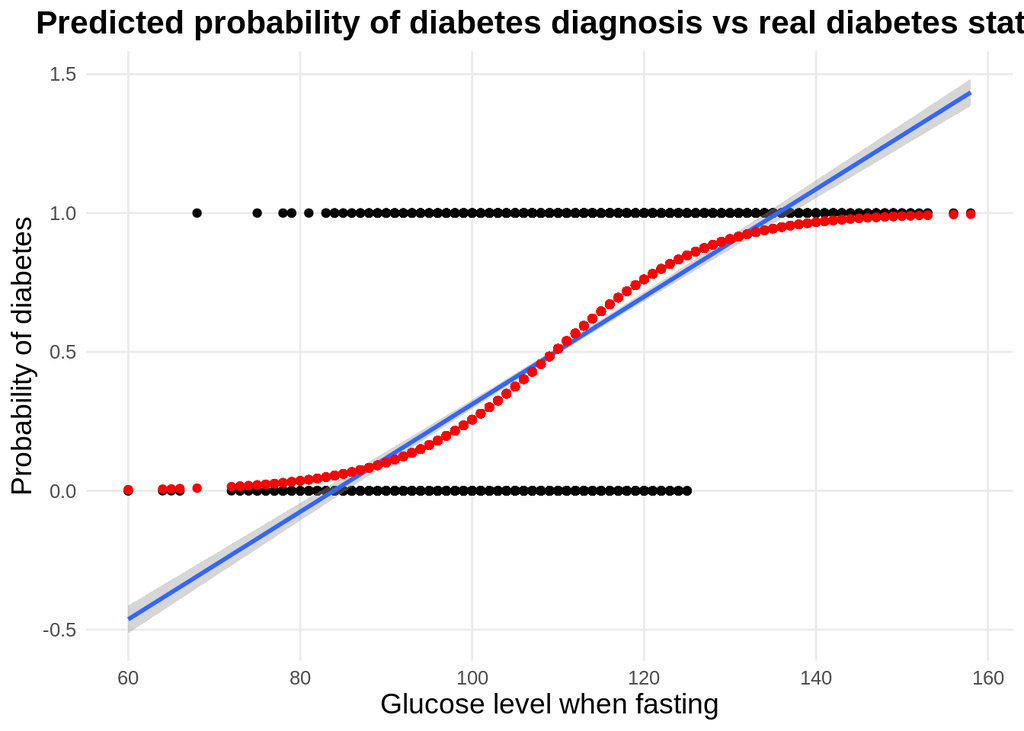

Как мы видим, у пациентов с диагностированным диабетом уровень глюкозы в среднем выше, чем у пациентов, не страдающих данным заболеванием. Построенная нами модель в теории может быть использована для прогнозирования развития диабета у пациентов, однако нам также предстоит изучить влияние не только биохимических показателей, чтобы повысить точность модели.

# 4 Выводы

Было выявлено, что наследственность, возраст, ИМТ и уровень физической активности влияют на уровень hba1c у пациентов. Также нам удалось установить, что социальные факторы, такие как уровень образования, дохода, наличие работы или национальность не влияют на уровень инсулина и на эти параметры нельзя опираться при оценке риска развития диабета.

Построенные модели позволяют утверждать, что уровень физической активности при взаимодействии с семейной историей диабета на оказывает значимого влияния на уровень hba1c. При этом явно существуют другие предикторы этого параметра, которые не были определены в данной работе.

Также было установлено, что среди биохимических показателей на риск возникновения диабета достоверно влияет только уровень глюкозы в крови. Несмотря на то, что этот фактор можно использовать для предсказания риска развития заболевания, в дальнейшем следует изучить другие возможные его предикторы.

## 4.1 Использованные пакеты

Обоснование других использовавшихся пакетов:

library(tidyr): - Использовался для преобразования структуры данных

- В разделе EDA: pivot_longer() для преобразования данных в длинный формат перед построением boxplot’ов выбросов
- В визуализации гипотезы 2: pivot_longer() для подготовки данных к построению facet-графиков

library(flextable):

- Применялся для создания профессионально оформленных таблиц
- Использовался для отображения типов переменных, результатов ANOVA, описательных статистик
- Позволял создавать таблицы с заголовками, форматированием чисел и выравниванием

library(tibble):

- Использовался для работы с современным форматом данных tibble
- as.tibble() применялся для преобразования результатов статистических тестов в удобный формат
- rownames_to_column() использовался для сохранения названий строк как отдельной переменной

library(readr):

- Отвечал за чтение данных: read_csv(“dataset_1_diabetes.csv”)
- Обеспечивал быструю и эффективную загрузку CSV-файла с автоматическим определением типов данных

library(corrplot):

- Использовался для визуализации матрицы корреляций
- Создавал наглядную тепловую карту корреляций между числовыми переменными
- Позволял отображать числовые значения коэффициентов корреляции на графике

library(lmtest):

- Применялся для диагностики регрессионных моделей
- bptest() - тест Бройша-Пагана для проверки гомоскедастичности остатков
- dwtest() - тест Дарбина-Уотсона для проверки автокорреляции остатков
- Обеспечивал статистическую проверку допущений линейных моделей

[output not shown]

[output cut: 101 more lines]

[output not shown]